# Estimating the shooting efficiency of top NBA point guard

# Results

```r
ilogit <-  function(x) 1/(1+exp(-x))

get_player_posterior_probs <- function(df, data, player_row_id) {
  beta.Year <- df[,paste('beta.Year[', player_row_id, ']', sep = '')]
  player.Effect <- df[,paste('Player.Effect[', player_row_id, ']', sep = '')]

  ## HARD_CODED to 3
  posterior_0 <- numeric(nrow(df))
  posterior_PRIOR_1 <- numeric(nrow(df))
  posterior_PRIOR_2 <- numeric(nrow(df))

  ## HARD_CODED to Experience
  col_names <- get_column_names("EXP")

  for (s in 1:nrow(df)) {
    posterior_0[s] <- ilogit(beta.Year[s] * data[player_row_id, col_names[1]] + player.Effect[s])
    posterior_PRIOR_1[s] <- ilogit(beta.Year[s] * data[player_row_id, col_names[2]] + player.Effect[s])
    posterior_PRIOR_2[s] <- ilogit(beta.Year[s] * data[player_row_id, col_names[3]] + player.Effect[s])
  }
  posterior <- cbind(posterior_0, posterior_PRIOR_1, posterior_PRIOR_2)

  return(posterior)
}

get_player_posterior_vs_observed <- function(data, player_row_id, posterior) {
  posterior_means <- apply(posterior, 2, mean)

  df_compare <- data.frame(posterior = as.vector(posterior_means),
                             observed = as.vector(as.matrix(data[player_row_id, get_column_names("FG%")])))
  rownames(df_compare) <- get_column_names("YEAR")

  return (df_compare)
}

plot_player_posterior_probs <- function(data, player_row_id, posterior) {
  plot1 <- densityplot(posterior[,"posterior_0"],
            panel = function(x, ...) {
             panel.densityplot(x, ...)
              panel.abline(v = mean(x), col.line = "blue")
              panel.abline(v = data[player_row_id, "FG%_0"], col.line = "red")
            },
            xlab = paste("Posterior probability", INTERESTED_YEARS[1])
            )
  plot2 <- densityplot(posterior[,"posterior_PRIOR_1"],
            panel = function(x, ...) {
             panel.densityplot(x, ...)
              panel.abline(v = mean(x), col.line = "blue")
              panel.abline(v = data[player_row_id, "FG%_PRIOR_1"], col.line = "red")
            },
            xlab = paste("Posterior probability", INTERESTED_YEARS[2])
            )
  plot3 <- densityplot(posterior[,"posterior_PRIOR_2"],
            panel = function(x, ...) {
             panel.densityplot(x, ...)
              panel.abline(v = mean(x), col.line = "blue")
              panel.abline(v = data[player_row_id, "FG%_PRIOR_2"], col.line = "red")
            },
            xlab = paste("Posterior probability", INTERESTED_YEARS[3])
            )

  grid.arrange(plot1, plot2, plot3, ncol = 3, nrow = 1)
}
```

## Check Stephen Curry successfully makes an attempted field goal for the past three years.

```r
player_row_id <- which(model_data$Player == "Stephen Curry")
# posterior prob
posterior <- get_player_posterior_probs(df, model_data, player_row_id)
```

```r
df_posterior_observed <- get_player_posterior_vs_observed(model_data, player_row_id, posterior)
df_posterior_observed
```

```
##              posterior  observed
## YEAR_0       0.4862059 0.4677755
## YEAR_PRIOR_1 0.4858598 0.5037547
## YEAR_PRIOR_2 0.4855228 0.4869500
```

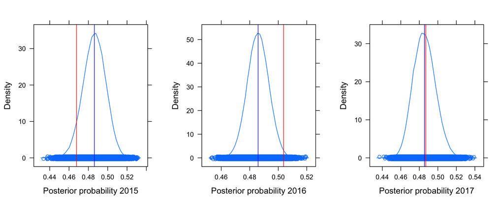

```r
plot_player_posterior_probs(model_data, player_row_id, posterior)
```

## Check Bradley Beal successfully makes an attempted field goal for the past three years.

```r
player_row_id <- which(model_data$Player == "Bradley Beal")
# posterior prob
posterior <- get_player_posterior_probs(df, model_data, player_row_id)
```

```r
df_posterior_observed <- get_player_posterior_vs_observed(model_data, player_row_id, posterior)
df_posterior_observed
```

```
##              posterior  observed
## YEAR_0       0.4779962 0.4818457
## YEAR_PRIOR_1 0.4540261 0.4493116
## YEAR_PRIOR_2 0.4303077 0.4265570
```

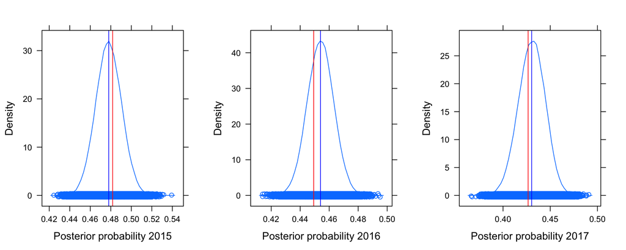

```r
plot_player_posterior_probs(model_data, player_row_id, posterior)
```

## Check DeMar DeRozan successfully makes an attempted field goal for the past three years.

```r
player_row_id <- which(model_data$Player == "DeMar DeRozan")
posterior <- get_player_posterior_probs(df, model_data, player_row_id)
df_posterior_observed <- get_player_posterior_vs_observed(model_data, player_row_id, posterior)
df_posterior_observed
```

```
##              posterior  observed
## YEAR_0       0.4617780 0.4666667
## YEAR_PRIOR_1 0.4440301 0.4458969
## YEAR_PRIOR_2 0.4264649 0.4131313
```

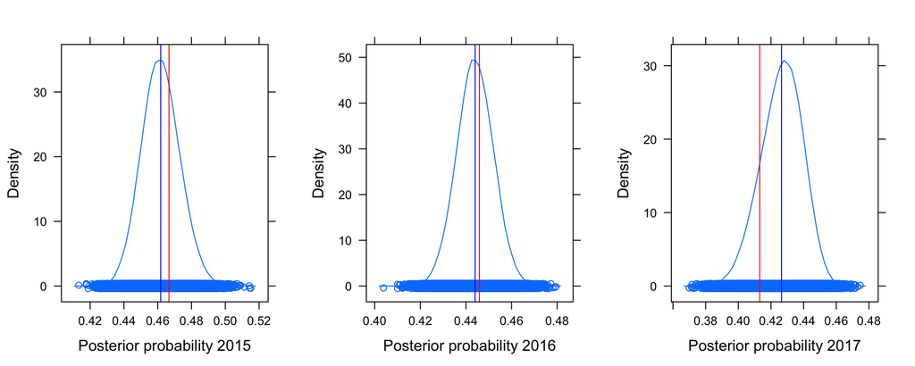

```r
plot_player_posterior_probs(model_data, player_row_id, posterior)
```

## Check Dennis Schroder successfully makes an attempted field goal for the past three years.

```r
player_row_id <- which(model_data$Player == "Dennis Schroder")
posterior <- get_player_posterior_probs(df, model_data, player_row_id)
df_posterior_observed <- get_player_posterior_vs_observed(model_data, player_row_id, posterior)
df_posterior_observed
```

```
##              posterior  observed
## YEAR_0       0.4468444 0.4510288
## YEAR_PRIOR_1 0.4336560 0.4212548
## YEAR_PRIOR_2 0.4206233 0.4270677
```

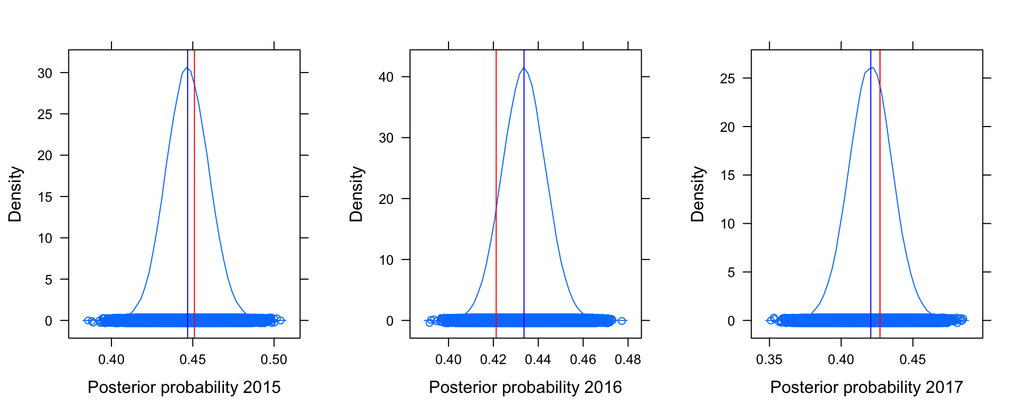

```r
plot_player_posterior_probs(model_data, player_row_id, posterior)
```

# Appendix

- [NBA Dataset](https://www.kaggle.com/drgilermo/nba-players-stats/downloads/nba-players-stats-since-1950.zip)
- [Basketball reference glossary](https://www.basketball-reference.com/about/glossary.html)